# HW #1

Orla O’Brien

2022-09-10

## Question 1.21: Categorize 5 scope of statistical inference in 5 papers

### Paper 1

*Logan RK, Vaudo JJ, Sousa LL,Sampson M, Wetherbee BM and Shivji MS (2020) Seasonal Movements and Habitat Use of Juvenile Smooth Hammerhead Sharks in the Western North Atlantic Ocean and Significance for Management. Front. Mar. Sci. 7:566364. doi: 10.3389/fmars.2020.566364*

This paper sampled by catching sharks via rod and reel. They caught 6 sharks, all were female juveniles. Because they only sampled in one place, using one method, during a short time window, I would say that both allocation of units to groups and selection of units were not random. My perception of this is also driven by the fact that they only caught sharks of a single demographic group – if they had caught a wider variety of sharks, I think it would have seemed more like they were getting a random sample.

As to whether or not they draw inferences beyond the scope of the analysis, I would say it is mixed. In a few key paragraphs, the authors do make sure to specify that they have drawn conclusions on “juvenile smooth hammerheads”. However, in much of the discussion, conclusions for just “smooth hammerheads” are discussed, without mentioning that the sample was only female juveniles from a very specific area. I think the discussion could have benefited from more discussion about the differences the authors might expect to see between juveniles/adults, females/males, and population differences.

### Paper 2

*Crowe, L. M., Brown, M. W., Corkeron, P. J., Hamilton, P. K., Ramp, C., Ratelle, S., … & Cole, T. V. (2021). In plane sight: a mark-recapture analysis of North Atlantic right whales in the Gulf of St. Lawrence. Endangered Species Research, 46, 227-251.*

The authors use four years of mark-recapture data on right whales in the Gulf of St. Lawrence. In this design, there is an assumed equal capture probability between marked and unmarked animals, and the authors tested for independence among subsets of the data, and concluded that capture heterogeneity (trap-dependence), presence of transient animals, and overdispersion of the data were not a factor. I would say that this design fits with selection of units at random, but allocation of units to groups not by randomization. This is because the random sample is analyzed as a whole, not split up or sub-sampled.

In the discussion, the authors addressed whether or not their initial assumptions were violated. In the case of whether or not capture/recapture probabilities were random, they posited that whatever drivers of capture probability exist (most likely, prey distribution), those affect the study population evenly. In addition, they found that their study population did not seem to differ from the total population in key demographic parameters. Thus, they are probably able to make inferences about this population in so far as it interacts with the study area (although they would not be able to extend inferences outside of the study area). The authors do a good job of outlining where these assumptions break down, for instance, during fall and winter seasons when there are fewer data available.

### Paper 3

*Bishop AL, Crowe LM, Hamilton PK and Meyer-Gutbrod EL (2022) Maternal Lineage and Habitat Use Patterns Explain Variation in the Fecundity of a Critically Endangered Baleen Whale. Front. Mar. Sci. 9:880910. doi: 10.3389/fmars.2022.880910*

The authors examine the potential effect of a summer feeding habitat on female right whale reproductive success. The dataset draws from all known right whale births – while it is likely that most births are detected on the calving grounds, the authors are not able to include data on failed pregnancies, or deaths of calves soon after birth. In addition, some calves are not detected until they are seen later in the year on feeding grounds, and mothers and calves that do not frequent the most highly survey feeding grounds are much less likely to be sighted and included in this study. I would say that the design of this study is not random either in the selection of units or the allocation of units to groups. For instance, there are many more factors that could affect an individual whale’s fecundity than feeding habitat preference: health history, stress levels, epigenetic effects related to their mother’s history, etc. Of course, it would be difficult to randomize this in an observational study, although these could be included as factors in the analysis.

In the discussion, the authors recognize that they are only looking at a subset of the population using a single habitat, and that comparisons are limited because of this. The authors also consider that there are many factor’s they were not able to include in the analyses, and that the scope of the conclusions is limited by this. Thus, I think the authors did a good job of staying within the bounds of their analyses.

### Paper 4

*Stepanuk, J. E., Heywood, E. I., Lopez, J. F., DiGiovanni Jr, R. A., & Thorne, L. H. (2021). Age-specific behavior and habitat use in humpback whales: implications for vessel strike. Marine Ecology Progress Series, 663, 209-222.*

This study uses humpback whale sightings collected from line transect vessel surveys. This design is not random in either selection of units or allocation of units to groups, because they take their sample population (not random) and place the animals into predefined demographic bins in order to analyze difference in feeding behaviors, in a specific geographic area. While this limits the scope of the conclusions, it seems like the authors recognize this. They discuss that demographic differences in behavior are likely to put juvenile humpback whales in this area at greater risk of vessel strike, and compare this to the higher mortality of juvenile humpbacks compared to adults during the study period.

### Paper 5

*Hodge, B. C., Pendleton, D. E., Ganley, L. C., O’Brien, O., Kraus, S. D., Quintana‐Rizzo, E., & Redfern, J. V. (2022). Identifying predictors of species diversity to guide designation of marine protected areas. Conservation Science and Practice, 4(5), e12665.*

In this study, marine mammal species diversity is assessed in 500 randomly selected sites on the east coast of the North Atlantic. These sites are then placed into their ecological production unit and several factors that could affect species diversity are considered (salinity, temperature, etc). The selection of units is random, but the allocation of units to groups is not. In the discussion, the author’s noted that while one of these factors, distance from the shelf edge, seemed to be a strong predictor of marine mammal diversity, there were differences in shelf edge characteristics within each ecological production unit (test group) that could also be having an impact.

## Question 1.27: Differences in voting records between Parties

Load in data and check that it looks ok

```
## 'data.frame':    112 obs. of  10 variables:
##  $ State   : chr  "Alabama" "Alabama" "Alaska" "Alaska" ...
##  $ Senator : chr  "Session" "Shelby" "Murkowski" "Stevens" ...
##  $ Party   : Factor w/ 3 levels "D","I","R": 3 3 3 3 3 3 1 1 1 1 ...
##  $ Pro2005 : int  1 1 2 1 1 9 13 12 18 18 ...
##  $ Anti2005: int  18 19 17 19 19 11 7 8 1 2 ...
##  $ Pro2006 : int  0 0 1 1 2 2 3 3 7 7 ...
##  $ Anti2006: int  7 7 6 6 5 4 4 4 0 0 ...
##  $ Pro2007 : int  2 1 6 4 2 0 10 9 12 13 ...
##  $ Anti2007: int  13 14 9 11 13 15 5 6 3 2 ...
##  $ PctPro  : num  7.32 4.76 21.95 14.29 11.9 ...
```

Look at a box plot to compare the average percent of positive votes by the three parties

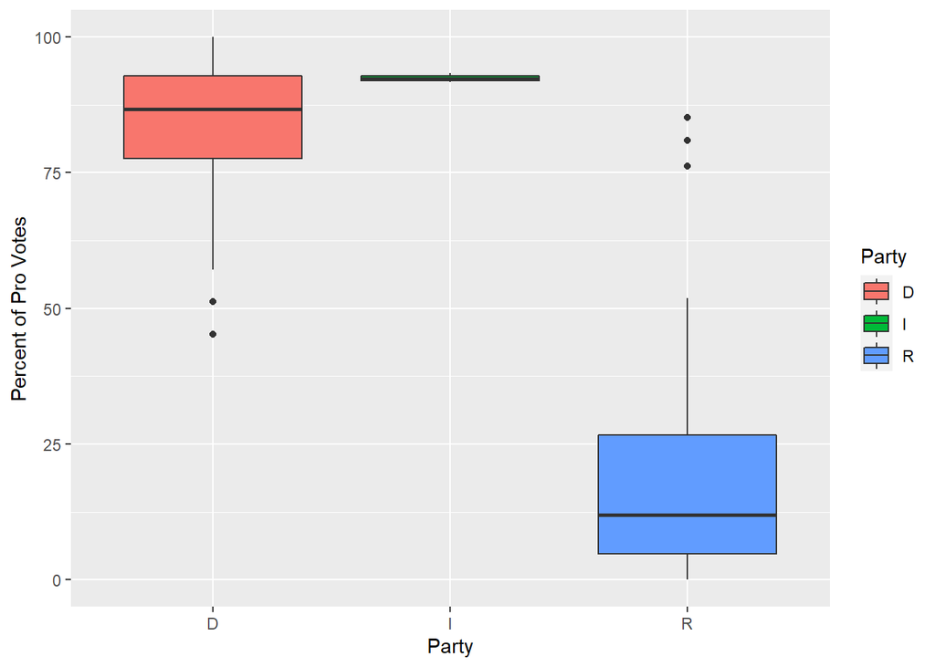

```
## # A tibble: 3 x 8
##   .y.    group1 group2        p   p.adj p.format p.signif method
##   <chr>  <chr>  <chr>     <dbl>   <dbl> <chr>    <chr>    <chr>
## 1 PctPro D      I      1.64e- 1 1.6e- 1 0.1642   ns       Wilcoxon
## 2 PctPro D      R      4.61e-18 1.4e-17 <2e-16   ****     Wilcoxon
## 3 PctPro I      R      3.91e- 3 7.8e- 3 0.0039   **       Wilcoxon
```

I wanted to try a histogram as well to view the spread of the data more easily

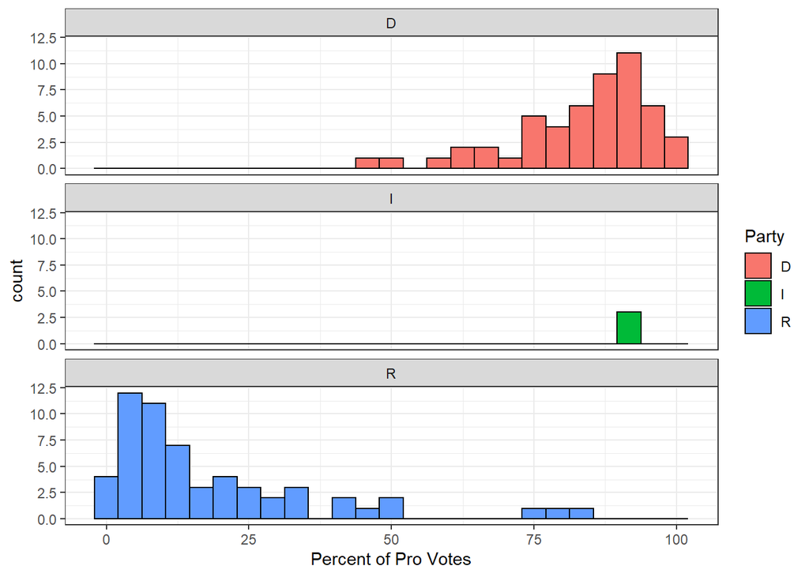

Lastly I printed the summary statistics

```
##   Party   min     Q1 median    Q3    max     mean         sd  n missing
## 1     D 45.24 77.585  86.67 92.86 100.00 83.64135 12.5130385 52       0
## 2     I 91.67 91.990  92.31 92.82  93.33 92.43667  0.8372176  3       0
## 3     R  0.00  4.760  11.90 26.67  85.19 18.54579 19.9564486 57       0
```

## Question 1.16: Distance of planets from the sun

First, read in the data. This was a little tricky since many exercise numbers are shared between Sleuth 2 and 3!

Plot the data

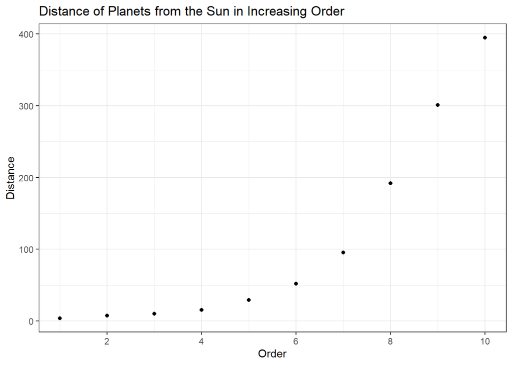

Use mutate function to add the variable “lnDist”

Then plot this new data set

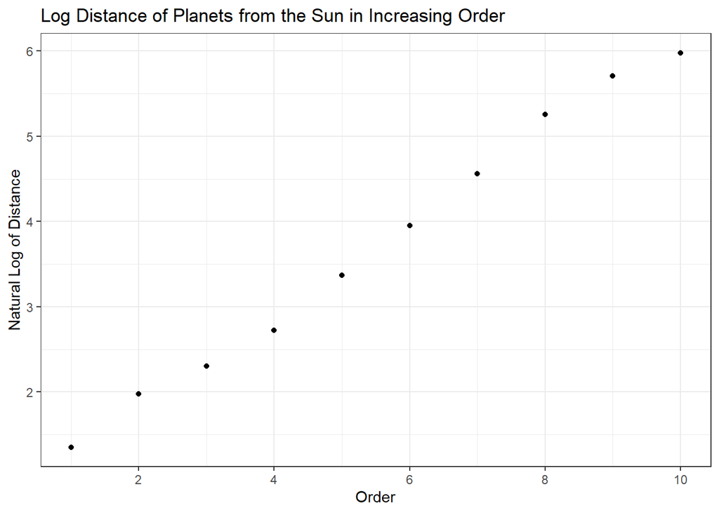

Print the summary statistics for both distance, and log of distance

```
##    Order    min     Q1 median     Q3    max   mean sd n missing
## 1      1   3.87   3.87   3.87   3.87   3.87   3.87 NA 1       0
## 2      2   7.23   7.23   7.23   7.23   7.23   7.23 NA 1       0
## 3      3  10.00  10.00  10.00  10.00  10.00  10.00 NA 1       0
## 4      4  15.24  15.24  15.24  15.24  15.24  15.24 NA 1       0
## 5      5  29.00  29.00  29.00  29.00  29.00  29.00 NA 1       0
## 6      6  52.03  52.03  52.03  52.03  52.03  52.03 NA 1       0
## 7      7  95.46  95.46  95.46  95.46  95.46  95.46 NA 1       0
## 8      8 192.00 192.00 192.00 192.00 192.00 192.00 NA 1       0
## 9      9 300.90 300.90 300.90 300.90 300.90 300.90 NA 1       0
## 10    10 395.00 395.00 395.00 395.00 395.00 395.00 NA 1       0
```

```
##    Order      min       Q1   median       Q3      max     mean sd n missing
## 1      1 1.353254 1.353254 1.353254 1.353254 1.353254 1.353254 NA 1       0
## 2      2 1.978239 1.978239 1.978239 1.978239 1.978239 1.978239 NA 1       0
## 3      3 2.302585 2.302585 2.302585 2.302585 2.302585 2.302585 NA 1       0
## 4      4 2.723924 2.723924 2.723924 2.723924 2.723924 2.723924 NA 1       0
## 5      5 3.367296 3.367296 3.367296 3.367296 3.367296 3.367296 NA 1       0
## 6      6 3.951820 3.951820 3.951820 3.951820 3.951820 3.951820 NA 1       0
## 7      7 4.558707 4.558707 4.558707 4.558707 4.558707 4.558707 NA 1       0
## 8      8 5.257495 5.257495 5.257495 5.257495 5.257495 5.257495 NA 1       0
## 9      9 5.706778 5.706778 5.706778 5.706778 5.706778 5.706778 NA 1       0
## 10    10 5.978886 5.978886 5.978886 5.978886 5.978886 5.978886 NA 1       0
```

## Question 1.26b: Plot two groups of rat treatments

First need to manually read in the data

```
##       A    B
## 1  1.31 1.13
## 2  1.45 1.71
## 3  1.12 1.39
## 4  1.16 1.15
## 5  1.30 1.33
## 6  1.50 1.00
## 7  1.20 1.03
## 8  1.22 1.68
## 9  1.42 1.76
## 10 1.14 1.55
## 11 1.23 1.34
## 12 1.59 1.47
## 13 1.11 1.74
## 14 1.10 1.74
## 15 1.53 1.19
## 16 1.52 1.15
## 17 1.17 1.20
## 18 1.49 1.59
## 19 1.62 1.47
## 20 1.29   NA
```

This format doesn’t work for a boxplot though, so you have to pivot the data. Probably you could read it in correctly the first time, but a dataframe is easier to work with in general.

```
## # A tibble: 40 x 2
##    Group Zinc_Level
##    <chr>      <dbl>
##  1 A           1.31
##  2 B           1.13
##  3 A           1.45
##  4 B           1.71
##  5 A           1.12
##  6 B           1.39
##  7 A           1.16
##  8 B           1.15
##  9 A           1.3
## 10 B           1.33
## # ... with 30 more rows
```

Now we are ready to plot the data.

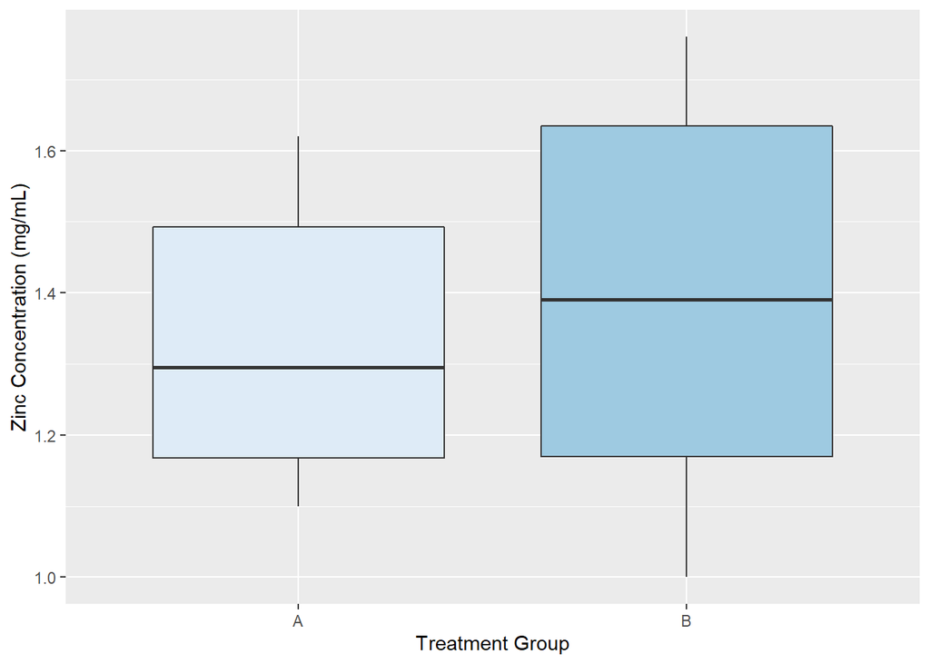